# Data Analytics Final Project

Juan de Wet

# Libraries

```r
# Installing Required Libraries

library(tidyverse)
library(dplyr)
```

# Summary

> Whenever doing something dangerous such as driving, flying, or even taking a ride on any public transportation such as trains there is a certain level of assumed risk. This assumption of risk is the legal amount of risk that you are expected to take as a user of certain services. This is saying that when you do something like go-karting, and then crash the kart injuring yourself, that is your fault. When you choose to get on the kart you take on a certain level of assumed risks. That same assumed risk is often overlooked for roller coasters. In reality steel roller coasters are the most dangerous of all amusement park rides, and this ride, amongst others like it, should still be handled like a dangerous ride. That means following very strictly any rules that may be given and practicing personal safety practices. While amusement parks do pose a danger that may be unknown to most, amusement parks are not fundamentally dangerous. This doesn’t mean that you shouldn’t go to amusement parks or that you shouldn’t ever ride a roller coaster during the month of June. However, when going to amusement parks one should always stay aware and alert when riding any kind of ride. This is similar to the commonly understood idea of being extra cautious when traveling during certain holidays. During certain holidays there are more cars on the road making the likelihood of small accidents happening much higher. This same extra level of caution should always be taken on certain rides like steel coasters and especially during the summer months. This little extra step of caution helps to keep yourself and everyone around you safe and can protect your liability in any kind of incident.

# Purpose

> The purpose of this study is to try and determine if there are any amusement parks or rides in the United States that could potentially be dangerous. This could be anything from one location with a strangely high number of injuries to a certain ride vehicle that has a pattern of injuring users. Any other patterns that help to provide any useful information on the amusement parks is also very important. Any of this could help show an array of information such as best or worst times to visit, best ages to visit amusement parks, and even if accidents on amusement park rides are just a matter of chance.

# Data

```r
# Renaming data file to help keep the data clean and clear.
safeparks_dataset <- read.csv("C:/Users/dewet/OneDrive - The Ohio State University/Documents/Foundations_DA/Saferparks-dataset-2017-v4 (1).csv")
```

> The overall dimensions of the data

```r
dim(safeparks_dataset)
```

```
[1] 8351   23
```

# A dictionary with all features and data set along side a breif overlay.

```r
safepark_dictionary <- data.frame(
  Variable = c("acc_id", "acc_date", "acc_state", "acc_city", "device_type", "num_injured", "total_injured", "state_injuries", "five_state_injuries", "city_injuries", "five_city_injuries", "top_citites_injuries", "age_youngest", "device_injuries"),
  Description = c(
    "Exact Accident identifier",
    "Date of the accident",
    "The State where the accident occurred",
    "The City where the accident occured",
    "The type of device involved",
    "Number of people injured in the accident",
    "The total number of people that were injured",
    "The total number of injuries for each state",
    "The five states with the most injuries",
    "Every city in the top five states for injuries",
    "The five cities with the most injuries from the five states with the most injuries",
    "The ten cities with the most injuries ",
    "Age of the youngest individual involved",
    "The type of amusement park device involved"
  ),
  DataType = c("Numerical", "Categorical", "Categorical", "categorical", "categorical", "Numerical", "Numerical", "Numerical", "Numerical", "Categorical", "categorical", "categorical", "Numerical", "categorical"),
  Units = c(
    "ID Number",
    "Date",
    "State Code",
    "City Name",
    "Device Type",
    "Number of People",
    "Number of People",
    "Number of Injuries",
    "Number of Injuries",
    "City Name",
    "City Name",
    "City Name",
    "Years",
    "Device Type"
  )
)
print(safepark_dictionary)
```

| Variable | Description | DataType | Units |
| --- | --- | --- | --- |
| acc_id | Exact Accident identifier | Numerical | ID Number |
| acc_date | Date of the accident | Categorical | Date |
| acc_state | The State where the accident occurred | Categorical | State Code |
| acc_city | The City where the accident occured | categorical | City Name |
| device_type | The type of device involved | categorical | Device Type |
| num_injured | Number of people injured in the accident | Numerical | Number of People |
| total_injured | The total number of people that were injured | Numerical | Number of People |
| state_injuries | The total number of injuries for each state | Numerical | Number of Injuries |
| five_state_injuries | The five states with the most injuries | Numerical | Number of Injuries |
| city_injuries | Every city in the top five states for injuries | Categorical | City Name |

[output cut: 4 more lines]

# Exploratory Data Analysis

# Total Injured By Device Type

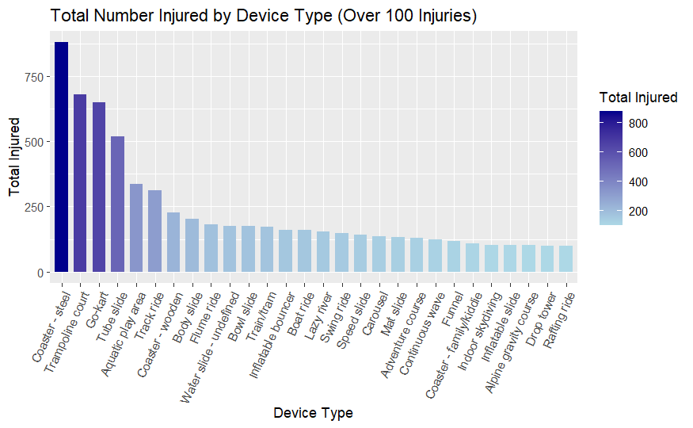

```r
device_injuries <- safeparks_dataset %>%
  group_by(device_type) %>%
  summarise(total_injured = sum(num_injured, na.rm = TRUE)) %>%
  filter(total_injured > 100)

ggplot(device_injuries, aes(x = reorder(device_type, -total_injured), y = total_injured, fill = total_injured)) +
  geom_bar(stat = "identity", width = 0.7) +
  scale_fill_gradient(low = "lightblue", high = "darkblue") +
  theme(axis.text.x = element_text(angle = 65, hjust = 1)) +
  labs(title = "Total Number Injured by Device Type (Over 100 Injuries)",
       x = "Device Type",
       y = "Total Injured",
       fill = "Total Injured")
```

> Above is a bar chart with every device type involved in an accident with over 100 injuries. The variable used for the x axis is device type and total injured is used for the y axis. Every device has a bar above it representing the total number of injured people related to that device. The rides represented with a darker blue on the left are the rides with the most injuries and the injuries become fewer as you go to the right and the bars become lighter. Looking at the higher bars in the data set you can quickly see that the three devices with the most injuries is steel roller coasters, trampoline courts, and go-karts. All three of these make sense that they would be the highest. Steel coasters have a reputation for being the biggest and fastest rides available. Trampoline parks are also a common place to get injured since especially small injuries like rug burns, whiplash, and sprains so easily occurred during such highly physical activities. Go-karts are typically designed to be made in a fashion that allows users to be safe but also allows users to bump into each other and crash themselves. Go-karts are also another version of a practice drivers course, but no drivers licence required and the cars don’t even have speedometers let alone cops to regulate everyone’s driving and speed.

# Number of Injuries by State

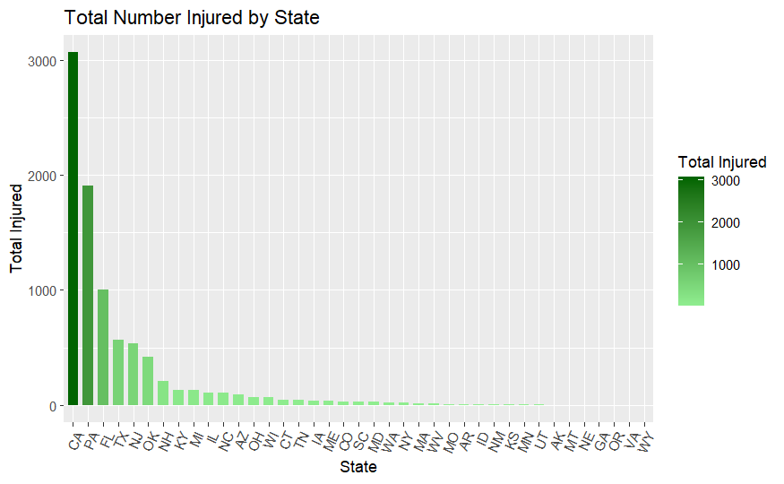

```r
state_injuries <- safeparks_dataset %>%
  group_by(acc_state) %>%
  summarise(total_injured = sum(num_injured, na.rm = TRUE)) %>%
  filter(total_injured >= 1) %>%
  arrange(desc(total_injured))

ggplot(state_injuries, aes(x = reorder(acc_state, -total_injured), y = total_injured, fill = total_injured)) +
  geom_bar(stat = "identity", width = 0.7) +
  scale_fill_gradient(low = "lightgreen", high = "darkgreen") +
  theme(axis.text.x = element_text(angle = 65, hjust = 1)) +
  labs(title = "Total Number Injured by State",
       x = "State",
       y = "Total Injured",
       fill = "Total Injured")
```

> In the chart above is a bar chart of every state with how many people have been injured in that state. The state of the incident is used for the x axis and the total injured within that state is used for the y axis. The chart is organized with the highest states to the left in dark green, and as the amount of injuries decrease to the right the green bar becomes lighter. This graph helps to eliminate any states that are not in need of concern for amusement park incidents mainly due to not having any large amusement parks in the state.

# States With the Most Injuries

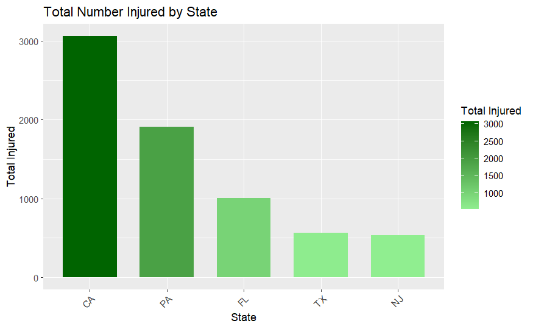

```r
five_state_injuries <- safeparks_dataset %>%
  group_by(acc_state) %>%
  summarise(total_injured = sum(num_injured, na.rm = TRUE)) %>%
  filter(total_injured >= 500) %>%
  arrange(desc(total_injured))

ggplot(five_state_injuries, aes(x = reorder(acc_state, -total_injured), y = total_injured, fill = total_injured)) +
  geom_bar(stat = "identity", width = 0.7) +
  scale_fill_gradient(low = "lightgreen", high = "darkgreen") +
  theme(axis.text.x = element_text(angle = 45, hjust = 1)) +
  labs(title = "Total Number Injured by State",
       x = "State",
       y = "Total Injured",
       fill = "Total Injured")
```

> Above is a narrowed version of the previous chart used to display the total injuries in every state. This bar chart shows only the five highest states in number of injuries using the same description and variables as the previous graph. Looking at just the top five states it is clear that certain states are much higher than the rest of the states with these five being the only states with over 500 injuries out of 50 states. California having by far the highest number of injuries compared to any state.

# City’s Total Injuries

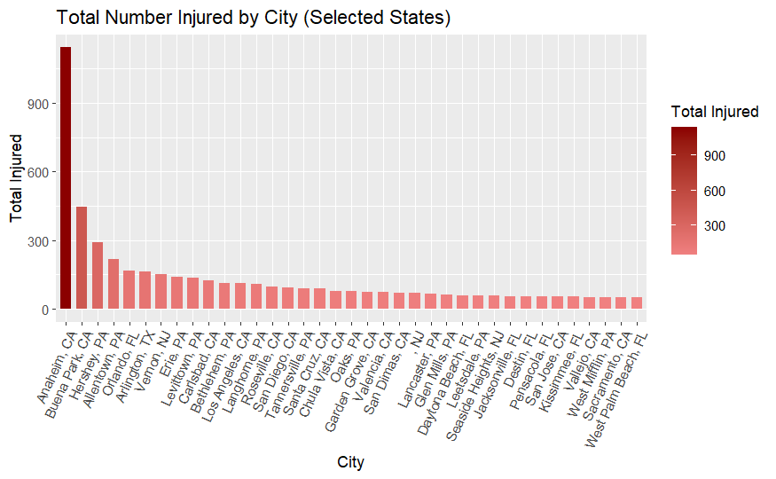

```r
city_injuries <- safeparks_dataset %>%
  filter(acc_state %in% c("CA", "PA", "FL", "TX", "NJ")) %>%
mutate(acc_city = paste(str_to_title(acc_city), acc_state, sep = ", ")) %>%  group_by(acc_city) %>%
  summarise(total_injured = sum(num_injured, na.rm = TRUE)) %>%
  filter(total_injured >= 50) %>%
  arrange(desc(total_injured))

ggplot(city_injuries, aes(x = reorder(acc_city, -total_injured), y = total_injured, fill = total_injured)) +
  geom_bar(stat = "identity", width = 0.7) +
  scale_fill_gradient(low = "lightcoral", high = "darkred") +
  theme(axis.text.x = element_text(angle = 65, hjust = 1)) +
  labs(title = "Total Number Injured by City (Selected States)",
       x = "City",
       y = "Total Injured",
       fill = "Total Injured")
```

> Above is a graph of every city within the top five states that had over 50 amusement park related injuries. To create the x axis the states and cities were used. For the y axis just total injury was used again. This data did show what cities have some kind of amusement park attraction or ride that had a fairly high number of guests injured. This helps show what cities may have plausible reasons for concern.

# Cities With Most Injuries

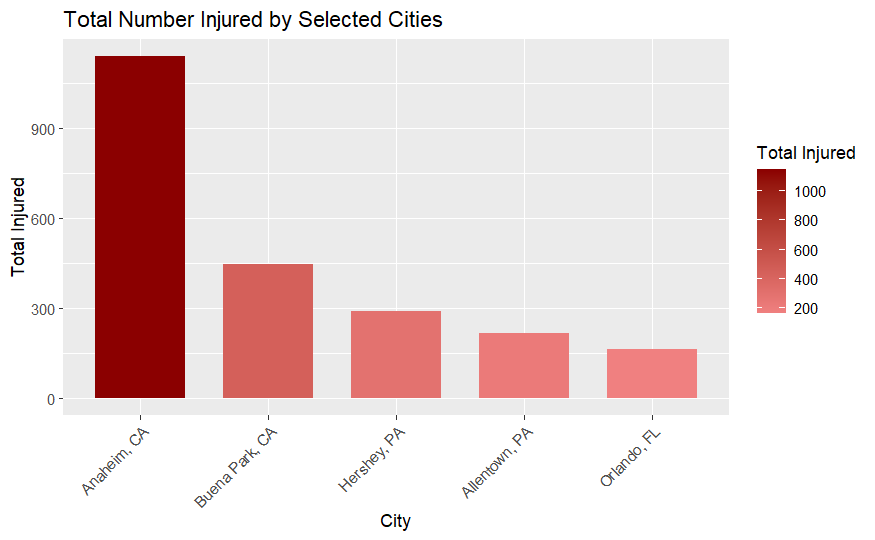

```r
five_city_injuries <- safeparks_dataset %>%
  filter(acc_city %in% c("Anaheim", "Buena Park", "Hershey", "Allentown", "ORLANDO")) %>%
  mutate(acc_city = case_when(
    acc_city == "Anaheim" ~ "Anaheim, CA",
    acc_city == "Buena Park" ~ "Buena Park, CA",
    acc_city == "Hershey" ~ "Hershey, PA",
    acc_city == "Allentown" ~ "Allentown, PA",
    acc_city == "ORLANDO" ~ "Orlando, FL",
    TRUE ~ acc_city)) %>%
  group_by(acc_city) %>%
  summarise(total_injured = sum(num_injured, na.rm = TRUE)) %>%
  arrange(desc(total_injured))

ggplot(five_city_injuries, aes(x = reorder(acc_city, -total_injured), y = total_injured, fill = total_injured)) +
  geom_bar(stat = "identity", width = 0.7) +
  scale_fill_gradient(low = "lightcoral", high = "darkred") +
  theme(axis.text.x = element_text(angle = 45, hjust = 1)) +
  labs(title = "Total Number Injured by Selected Cities",
       x = "City",
       y = "Total Injured",
       fill = "Total Injured")
```

> Taking a closer look into the cities with the most injuries I made the bar chart above to show the total injuries of the top five highest cities from the previous chart. This shows a few cities that most people would recognize these city names based on well known places there to visit. Anaheim has the most injuries out of all the cities and even has roughly more injuries than the remaining top five cities combined. This is because of DisneyLand being located in Anaheim. Since disney has such a large array of steel coasters, the most dangerous ride vehicle of amusement park rides, it makes sense that this heavily traveled to park would have a lot of injuries. However, taking into account that Orlando is the home of Disney World, the younger but bigger brother of DisneyLand, it could be cause for concern that Aneheim has such a higher rate of injuries.

# Ten Cities With Most Injuries Overall

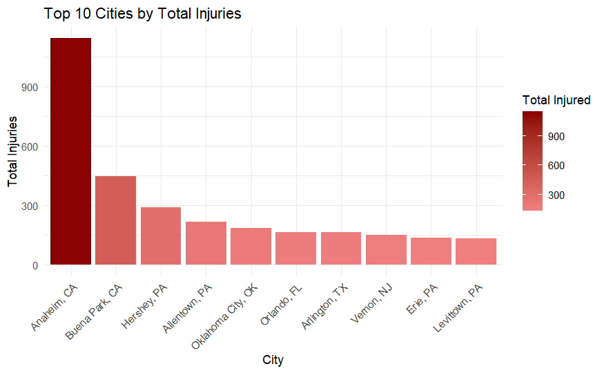

```r
top_cities_injuries <- safeparks_dataset %>%
  mutate(acc_city = paste(str_to_title(acc_city), acc_state, sep = ", ")) %>%
  group_by(acc_city) %>%
  summarise(total_injured = sum(num_injured, na.rm = TRUE)) %>%
  arrange(desc(total_injured)) %>%
  slice_head(n = 10)

ggplot(top_cities_injuries, aes(x = reorder(acc_city, -total_injured), y = total_injured, fill = total_injured)) +
  geom_col() +
  scale_fill_gradient(low = "lightcoral", high = "darkred") +
  labs(title = "Top 10 Cities by Total Injuries",
       x = "City",
       y = "Total Injuries",
       fill = "Total Injured") +
  theme_minimal() +
  theme(axis.text.x = element_text(angle = 45, hjust = 1))
```

> Very similar to the previous chart of the top five cities for injuries from the top five states. This chart above is the top ten cities from all of the cities in total injuries. The reason for this is to make sure that the top cities in injuries are not only in the states with the highest injuries. To test this I created the same chart using the same variables for the previous chart once again. For this chart it was not filtered from just the top five states and this chart shows the top ten cities to show how much the rankings could change once the parameters were widened. Despite changing the array of cities to filter from just five to fifty only one city from the previous top five cities moved one space. This is because the city of Oklahoma City is the overall fifth highest city in amusement park injuries. In the previous chart Orlando was the fifth city. This made sense since Orlando has the world’s most visited theme park. Unaware of any major theme parks in Oklahoma City and it being the only city within the top five cities no having an immediately known theme park may be a good reason to look further into Oklahoma City.

# Total Injuries for Every Month

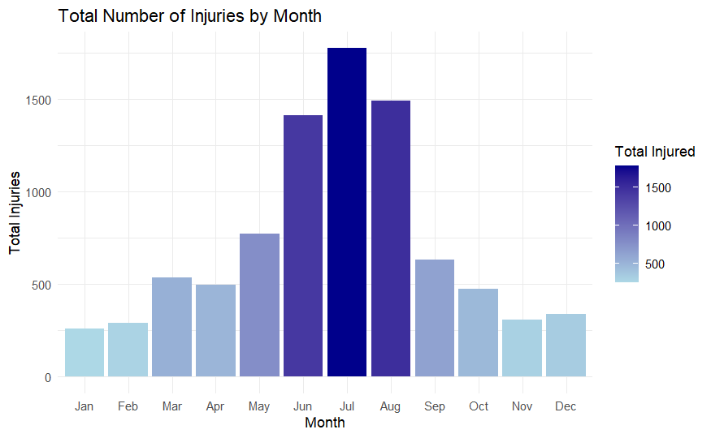

```r
safeparks_dataset$acc_month <- format(as.Date(safeparks_dataset$acc_date, format = "%m/%d/%Y"), "%m")


monthly_injuries <- safeparks_dataset %>%
  group_by(acc_month) %>%
  summarise(total_injured = sum(num_injured, na.rm = TRUE))

ggplot(monthly_injuries, aes(x = acc_month, y = total_injured, fill = total_injured)) +
  geom_col() +
  scale_fill_gradient(low = "lightblue", high = "darkblue") +
  labs(title = "Total Number of Injuries by Month",
       x = "Month",
       y = "Total Injuries",
       fill = "Total Injured") +
  scale_x_discrete(labels = month.abb) +
  theme_minimal()
```

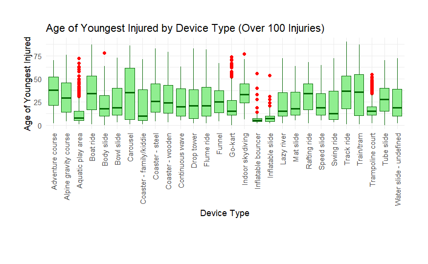

```r
filtered_data <- safeparks_dataset %>%
  group_by(device_type) %>%
  summarise(total_injured = sum(num_injured, na.rm = TRUE)) %>%
  filter(total_injured > 100) %>%
  inner_join(safeparks_dataset, by = "device_type")

ggplot(na.omit(filtered_data[, c("device_type", "age_youngest")]), aes(x = device_type, y = age_youngest)) +
  geom_boxplot(fill = "lightgreen", color = "darkgreen", outlier.color = "red", outlier.shape = 19) +
  theme_minimal() +
  theme(
    axis.text.x = element_text(angle = 90, vjust = 0.5, hjust = 1),
    plot.margin = margin(1, 1, 2, 1, "cm")
  ) +
  labs(
    title = "Age of Youngest Injured by Device Type (Over 100 Injuries)",
    x = "Device Type",
    y = "Age of Youngest Injured"
  )
```